# S05 T01: Transformació Registre Log amb Regular expressions

### Descripció

L'anàlisi de registres és una funció important per al control i l'alerta, el compliment de les polítiques de seguretat, l'auditoria i el compliment normatiu, la resposta a incidents de seguretat i fins i tot les investigacions forenses. En analitzar les dades de registre, les empreses poden identificar més fàcilment les possibles amenaces i altres problemes, trobar la causa arrel i iniciar una resposta ràpida per mitigar els riscos.

L'analista ha d'assegurar-se que els registres consisteixen en una gamma completa de missatges i s'interpreten segons el context. Els elements de registre han d'estandaritzar-se, utilitzant els mateixos termes o terminologia, per evitar confusions i proporcionar cohesió.

Com Científic de Dades se t'ha proporcionat accés als registres-Logs on queda registrada l'activitat de totes les visites a realitzades a la pàgina web de l'agència de viatges "akumenius.com".

### Exercici 1

Estandaritza, identifica i enumera cada un dels atributs / variables de l'estructura de l'arxiu "Web_access_log-akumenius.com" que trobaràs al repositori de GitHub "Data-sources".

Atés que els Common Log Format son arxius de text estandaritzats, cada línia guardada en aquest format té la següent sintaxis:

```
- host
- IP address
- RFC identifyer
- user id: serà '-' en cas de dominis públics.
- datetime, entre brackets []
- request, entre doble cometes " "
- status response:
    * 2xx: resposta satisfactòria
    * 3xx: redirigit
    * 4xx: error client
    * 5xx: error servidor
- bytes
- URL d'on prové l'usuari, entre doble cometes " "
- browser, entre doble cometes " ".
- cookies
```

Un '-' en qualsevol part de la línia indica dades faltants o 'NaN'.

```python
import numpy as np
import pandas as pd
import matplotlib.pyplot as plt
import seaborn as sns
import re

columns = ['domain', 'IP_address','RFC_id', 'user_id', 'datetime', 'request', 'status_response', 'bytes','from_URL', 'browser', 'cookies']

delimiter = r" (.+|-) (.+|-) (.+|-) \[(.*) \+0100\] (.+) (\d+|-) (\d+|-) \"(.+)\" \"(.+)\" VLOG="

txt = pd.read_csv("/Users/deliagonzalezmata/Documents/IT_Academy/Git_Data-Science/Data-sources/Web_access_log-akumenius.com.txt",
                 delimiter=delimiter,
                   engine="python",
                   names=columns,
                   na_values="-")

txt.sample(15)
```

|  | domain | IP_address | RFC_id | user_id | datetime | request | status_response | bytes | from_URL | browser | cookies |
| --- | --- | --- | --- | --- | --- | --- | --- | --- | --- | --- | --- |
| 179109 | www.akumenius.com | 79.145.213.52 | NaN | NaN | 26/Feb/2014:22:48:04 | "GET /libraries/jqueryui/js/jquery.ui.slider.m... | 304 | NaN | http://www.akumenius.com/hotel-list | Mozilla/4.0 (compatible; MSIE 8.0; Windows NT ... | NaN |
| 166486 | www.akumenius.com | 80.28.221.123 | NaN | NaN | 26/Feb/2014:15:33:22 | "GET /modules/raton/views/themes/bcoos/images/... | 304 | NaN | http://www.akumenius.com/hotel-list | Mozilla/5.0 (X11; U; Linux i686; ca; rv:1.9.2.... | NaN |
| 39442 | www.akumenius.com | 144.76.95.232 | NaN | NaN | 23/Feb/2014:23:26:56 | "GET /destinos-baratos/destinos-caracteristica... | 200 | 11371.0 | NaN | Mozilla/5.0 (compatible; MJ12bot/v1.4.4; http:... | NaN |
| 149178 | www.akumenius.com | 173.252.112.115 | NaN | NaN | 26/Feb/2014:02:31:28 | "GET /modules/raton/views/themes/bcoos/images/... | 200 | 208.0 | http://www.akumenius.com/destinosCaracteristic... | facebookexternalhit/1.1 (+http://www.facebook.... | NaN |
| 220837 | www.akumenius.com | 81.203.188.244 | NaN | NaN | 27/Feb/2014:22:04:20 | "GET /libraries/anythingSlider/images/2a.png H... | 200 | 2510.0 | http://www.akumenius.com/ | Mozilla/5.0 (Windows NT 6.1; WOW64; rv:27.0) G... | NaN |
| 172716 | localhost | 127.0.0.1 | NaN | NaN | 26/Feb/2014:18:56:44 | "OPTIONS * HTTP/1.0" | 200 | NaN | NaN | Apache (internal dummy connection) | NaN |
| 104401 | test.akumenius.com | 217.125.71.222 | NaN | NaN | 25/Feb/2014:12:40:48 | "GET /newdesign/libraries/anythingSlider/image... | 304 | NaN | http://test.akumenius.com/newdesign/ | Mozilla/5.0 (Windows NT 6.0; WOW64) AppleWebKi... | NaN |
| 88780 | www.akumenius.com | 87.219.136.85 | NaN | NaN | 24/Feb/2014:23:10:20 | "GET /modules/raton/views/themes/bcoos/images/... | 200 | 3638.0 | http://www.akumenius.com/destinos-baratos/hote... | Mozilla/5.0 (Windows NT 6.2; WOW64) AppleWebKi... | NaN |
| 163556 | www.akumenius.com | 195.53.184.207 | NaN | NaN | 26/Feb/2014:14:04:25 | "POST /destinos-get HTTP/1.1" | 200 | 219.0 | http://www.akumenius.com/ | Mozilla/5.0 (Windows NT 6.1; WOW64) AppleWebKi... | NaN |
| 233581 | www.akumenius.com | 157.55.32.89 | NaN | NaN | 28/Feb/2014:12:06:54 | "GET /escapadas/escapada-bodega-borda-sabate-h... | 200 | 3100.0 | NaN | Mozilla/5.0 (compatible; bingbot/2.0; +http://... | NaN |
| 102796 | www.akumenius.com | 77.224.108.21 | NaN | NaN | 25/Feb/2014:12:05:08 | "GET /modules/raton/views/themes/bcoos/images/... | 200 | 12237.0 | http://www.akumenius.com/booking/146677/b/Apol... | Mozilla/5.0 (compatible; MSIE 10.0; Windows NT... | NaN |
| 91195 | www.akumenius.com | 66.249.76.216 | NaN | NaN | 25/Feb/2014:01:52:57 | "GET /destinos-caracteristicas/hoteles-baratos... | 200 | 7222.0 | NaN | Mozilla/5.0 (compatible; Googlebot/2.1; +http:... | NaN |
| 32768 | www.akumenius.com | 66.249.76.216 | NaN | NaN | 23/Feb/2014:20:34:35 | "GET /destinos-caracteristicas/hoteles-baratos... | 200 | 14624.0 | NaN | Mozilla/5.0 (compatible; Googlebot/2.1; +http:... | NaN |
| 3039 | www.akumenius.com | 5.10.83.52 | NaN | NaN | 23/Feb/2014:04:28:25 | "GET /hoteles-baratos/ofertas-hotel-Roulette-C... | 404 | 3100.0 | NaN | Mozilla/5.0 (compatible; AhrefsBot/5.0; +http:... | NaN |
| 175326 | www.akumenius.com | 85.49.138.49 | NaN | NaN | 26/Feb/2014:20:14:06 | "GET /modules/raton/views/themes/bcoos/images/... | 200 | 5150.0 | http://www.akumenius.com/ | Mozilla/5.0 (Windows NT 6.3; WOW64) AppleWebKi... | NaN |

### Exercici 2

Neteja, preprocesa, estructura i transforma (dataframe) les dades del registre d'Accés a la web.

```python
txt.dtypes
```

```
domain              object
IP_address          object
RFC_id             float64
user_id             object
datetime            object
request             object
status_response      int64
bytes              float64
from_URL            object
browser             object
cookies            float64
dtype: object
```

```python
txt.info()
```

```
<class 'pandas.core.frame.DataFrame'>
RangeIndex: 261873 entries, 0 to 261872
Data columns (total 11 columns):
 #   Column           Non-Null Count   Dtype
---  ------           --------------   -----
 0   domain           261873 non-null  object
 1   IP_address       261873 non-null  object
 2   RFC_id           0 non-null       float64
 3   user_id          27 non-null      object
 4   datetime         261873 non-null  object
 5   request          261873 non-null  object
 6   status_response  261873 non-null  int64
 7   bytes            219538 non-null  float64
 8   from_URL         162326 non-null  object
 9   browser          261654 non-null  object
 10  cookies          0 non-null       float64
dtypes: float64(3), int64(1), object(7)
memory usage: 22.0+ MB
```

Veient que les columnes 'RFC_id' i 'cookies' només tenen valors nuls, les eliminem del dataset.

```python
txt = txt.drop('RFC_id', 1)
txt = txt.drop('cookies', 1)
```

```python
list(txt.columns)
```

```
['domain',
 'IP_address',
 'user_id',
 'datetime',
 'request',
 'status_response',
 'bytes',
 'from_URL',
 'browser']
```

### domain

Tenim 5 dominis entre tots els usuaris. El més popular és www.akumenius.com, mentre que akumenius.com i akumenius.es no semblen ser gaire utilitzats:

```python
txt.domain.value_counts()
```

```
www.akumenius.com     232300
test.akumenius.com     14610
localhost              14127
akumenius.com            742
akumenius.es              94
Name: domain, dtype: int64
```

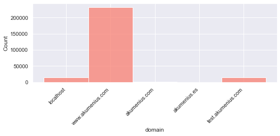

```python
domain_counts = txt.domain.value_counts()

sns.set(rc = {'figure.figsize':(9,3)})
sns.set(style='darkgrid')
sns.histplot(data = txt, x = 'domain', color = 'salmon')

plt.xticks(rotation = 45, horizontalalignment = 'right')

plt.show()
```

### IP_address

tenim 2.921 adreces IP diferents, que més endavant geolocalitzarem:

```python
 txt.IP_address.value_counts()
```

```
66.249.76.216      46382
80.28.221.123      14725
127.0.0.1          13892
217.125.71.222      5201
66.249.75.148       3558
                   ...
84.123.150.27          1
217.130.150.116        1
202.46.52.23           1
216.151.130.170        1
206.198.5.33           1
Name: IP_address, Length: 2921, dtype: int64
```

### user_id

com hem vist abans amb la funció txt.info() només hi han 27 registres de user_id i la resta son valors nuls. Comprovem quins registres han quedat guardats:

```python
print(txt.user_id.unique())
```

```
[nan 'clarcat']
```

### datetime:

la informació que se'ns dóna per defecte és del tipus:

```
'%d/%b/%Y:%H:%M:%S'
```

Abans hem vist que la columna anomenada datetime és del tipus 'object' dins la nostra BD. La transformem per a que tingui el tipus 'datetime' i poder treballar amb ella:

```python
txt['datetime'] = pd.to_datetime(txt['datetime'], format="%d/%b/%Y:%H:%M:%S")
txt.datetime.head()
```

```
0   2014-02-23 03:10:31
1   2014-02-23 03:10:31
2   2014-02-23 03:10:31
3   2014-02-23 03:10:31
4   2014-02-23 03:10:31
Name: datetime, dtype: datetime64[ns]
```

Un cop transformada la columna 'datetime' en el tipus que volem, dividirem la informació en 2 columnes diferents:

- una que contingui informació sobre la data (date)
- altra que contingui informació sobre l'hora (time)

```python
txt['date'] = txt['datetime'].dt.date
txt['time'] = txt['datetime'].dt.time

txt[['date','time']].sample(10)
```

|  | date | time |
| --- | --- | --- |
| 102599 | 2014-02-25 | 12:02:46 |
| 243233 | 2014-03-01 | 00:44:38 |
| 50075 | 2014-02-24 | 09:14:26 |
| 206084 | 2014-02-27 | 16:13:58 |
| 181908 | 2014-02-27 | 00:12:35 |
| 35611 | 2014-02-23 | 21:47:15 |
| 75083 | 2014-02-24 | 16:15:56 |
| 124947 | 2014-02-25 | 17:41:24 |
| 133495 | 2014-02-25 | 19:01:39 |
| 219690 | 2014-02-27 | 21:00:10 |

```python
txt[['date']].sort_index()
```

|  | date |
| --- | --- |
| 0 | 2014-02-23 |
| 1 | 2014-02-23 |
| 2 | 2014-02-23 |
| 3 | 2014-02-23 |
| 4 | 2014-02-23 |
| ... | ... |
| 261868 | 2014-03-02 |
| 261869 | 2014-03-02 |
| 261870 | 2014-03-02 |
| 261871 | 2014-03-02 |
| 261872 | 2014-03-02 |

261873 rows × 1 columns

Les dates entre les quals hem obtingut registres son la setmana del 23/02/2014 (diumenge) fins el 02/03/2014 (diumenge), ambdós inclosos.

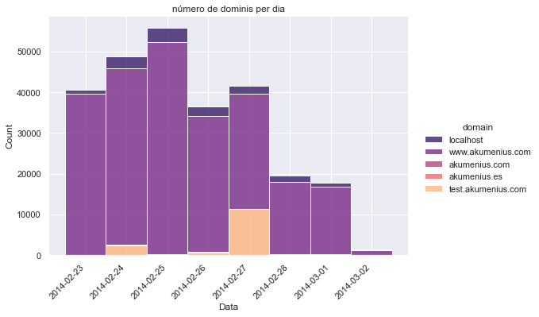

```python
sns.displot(data=txt, x='date', kind='hist', hue='domain', multiple='stack', palette='magma', aspect=1.5)

plt.title('número de dominis per dia')
plt.xlabel('Data')
plt.xticks(rotation = 45, horizontalalignment = 'right')

plt.show()
```

### request:

les files de la columna "request" mostren el requeriment del client. Estan formades per 3 parts:

- el mètode GET ('method')
- el recurs sol•licitat ('resource')
- el protocol HTTP ('http_protocol')

Crearem 3 noves col•lumnes que separin cada un dels elements:

```python
regex = re.compile(r"\"(?P<method>\w*) (?P<resource>[\/*].*?) (?P<http_protocol>.*?)\"")

df_request = txt['request'].str.extract(regex)
df_request.sample(10)
```

|  | method | resource | http_protocol |
| --- | --- | --- | --- |
| 177341 | GET | /includes/images/uploaded/ti_home.jpg | HTTP/1.1 |
| 30483 | POST | /destinos-get | HTTP/1.1 |
| 188561 | POST | /destinos-get | HTTP/1.1 |
| 148861 | GET | /modules/raton/views/themes/bcoos/images/logo_... | HTTP/1.1 |
| 242983 | OPTIONS | * | HTTP/1.0 |
| 246622 | GET | /libraries/jqueryui/css/ui-lightness/images/ui... | HTTP/1.1 |
| 186568 | GET | //libraries/anythingSlider/images/3a.png | HTTP/1.1 |
| 92892 | GET | /destinosCaracteristicas/hoteles-baratos-en-Ge... | HTTP/1.1 |
| 106911 | GET | /destinosCaracteristicas/hoteles-baratos-en-Ca... | HTTP/1.1 |
| 80812 | GET | /robots.txt | HTTP/1.1 |

```python
df_request.method.value_counts()
```

```
GET        229482
POST        16669
OPTIONS     13892
HEAD         1788
Name: method, dtype: int64
```

```python
df_request.http_protocol.value_counts()
```

```
HTTP/1.1    241991
HTTP/1.0     19840
Name: http_protocol, dtype: int64
```

### status_response

Els codis de resposta indiquen si s'ha completat satisfactoriament una sol•licitud o bé si hi ha hagut algun tipus d'error. Depenent de quin sigui el codi que s'imprimeix significa:

- 2xx: resposta satisfactòria
- 3xx: redirigit
- 4xx: error client
- 5xx: error servidor

Veiem les diferents respostes que hem obtingut mitjançant els registres proporcionats:

```python
txt.status_response.value_counts().sort_index()
```

```
200    226382
206       304
301       870
302       109
304     25269
400        26
401         5
403       194
404      8630
408        37
500         3
502        44
Name: status_response, dtype: int64
```

```python
error_2xx = (txt['status_response'].map(str)).str.extract(r'(^2)')
error_3xx = (txt['status_response'].map(str)).str.extract(r'(^3)')
error_4xx = (txt['status_response'].map(str)).str.extract(r'(^4)')
error_5xx = (txt['status_response'].map(str)).str.extract(r'(^5)')

print('codi tipus', error_2xx.value_counts())
print('codi tipus', error_3xx.value_counts())
print('codi tipus', error_4xx.value_counts())
print('codi tipus', error_5xx.value_counts())
```

```
codi tipus 2    226686
dtype: int64
codi tipus 3    26248
dtype: int64
codi tipus 4    8892
dtype: int64
codi tipus 5    47
dtype: int64
```

Així doncs, la gran majoria de sol•licituds han tingut una resposta satisfactòria. Veiem-ho en un gràfic:

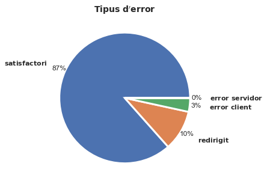

```python
total = txt['status_response'].count()
pct2 = (((error_2xx.value_counts()).values)/total)*100
pct3 = (((error_3xx.value_counts()).values)/total)*100
pct4 = (((error_4xx.value_counts()).values)/total)*100
pct5 = (((error_5xx.value_counts()).values)/total)*100

plt.rcParams["figure.figsize"] = (20,5)

labels = ('$\mathbf{satisfactori}$', '$\mathbf{redirigit}$', '$\mathbf{error \ client}$', '$\mathbf{error \ servidor}$')
values = [float(pct2), float(pct3), float(pct4), float(pct5)]

plt.pie(values, labels = labels, labeldistance = 1.3,
        wedgeprops = {'linewidth' : 3, 'edgecolor' : 'white'},
       autopct='%1.0f%%', pctdistance=1.1)

plt.title('$\mathbf{Tipus \ d\'error}$', fontsize = 14)
plt.show()
```

### bytes

```python
txt.bytes.describe().apply(lambda x: '%.5f' % x)
```

```
count      219538.00000
mean        11827.71290
std        241363.02380
min             1.00000
25%          2510.00000
50%          6407.00000
75%          9674.00000
max      45564687.00000
Name: bytes, dtype: object
```

```python
txt.bytes.isna().sum()
```

```
42335
```

```python
df_bytes = pd.DataFrame(columns = ['megabytes', 'date'])
df_bytes['megabytes'] = txt['bytes']/(2**10)/(2**10)

df_bytes['date'] = txt['date']

df_bytes.groupby('date').sum()
```

| date | megabytes |
| --- | --- |
| 2014-02-23 | 328.387009 |
| 2014-02-24 | 386.561088 |
| 2014-02-25 | 598.861448 |
| 2014-02-26 | 566.678618 |
| 2014-02-27 | 252.933409 |
| 2014-02-28 | 161.377036 |
| 2014-03-01 | 170.215617 |
| 2014-03-02 | 11.327437 |

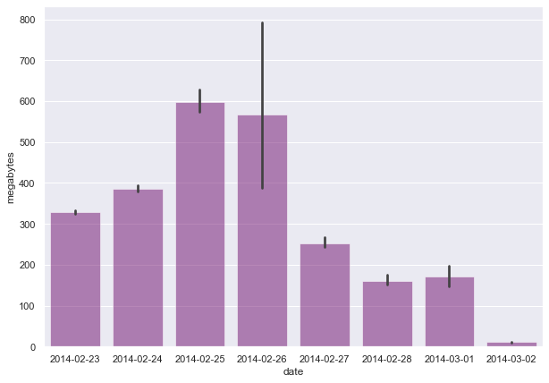

```python
# En format gràfic:
plt.figure(figsize=(10, 7))
sns.barplot(x='date', y='megabytes', data = df_bytes,
            estimator=sum, color='purple', alpha = 0.5);
```

### from_URL

les visites a la web d'akumenius han vingut referenciades des de 2.507 llocs webs diferents.

```python
txt.from_URL.unique().size
```

```
2507
```

### browser

```python
txt.browser.unique().size
```

```
735
```

### Exercici 3

Geolocalitza les IP's.

Com hem vist en l'exercici anterior, tenim 2.921 adreces IP diferents. Crearem una nova base de dades amb només les columnes relatives a l'adreça IP i quants cops han estat utilitzades

```python
df_IP = txt['IP_address'].value_counts().rename_axis('IP_address').reset_index(name='quantitat')
df_IP
```

|  | IP_address | quantitat |
| --- | --- | --- |
| 0 | 66.249.76.216 | 46382 |
| 1 | 80.28.221.123 | 14725 |
| 2 | 127.0.0.1 | 13892 |
| 3 | 217.125.71.222 | 5201 |
| 4 | 66.249.75.148 | 3558 |
| ... | ... | ... |
| 2916 | 84.123.150.27 | 1 |
| 2917 | 217.130.150.116 | 1 |
| 2918 | 202.46.52.23 | 1 |
| 2919 | 216.151.130.170 | 1 |
| 2920 | 206.198.5.33 | 1 |

2921 rows × 2 columns

Atès que localhost sempre es tradueix en l'adreça IP 127.0.0.1, podem eliminar-les del nostre data set i definir la resta com a public IP.

```python
def localhost (ip):
    if ip == '127.0.0.1':
        return 'local host'
    else:
        return 'public IP'

df_IP['IP_type'] = df_IP['IP_address'].apply(localhost)
df_IP.head()
```

|  | IP_address | quantitat | IP_type |
| --- | --- | --- | --- |
| 0 | 66.249.76.216 | 46382 | public IP |
| 1 | 80.28.221.123 | 14725 | public IP |
| 2 | 127.0.0.1 | 13892 | local host |
| 3 | 217.125.71.222 | 5201 | public IP |
| 4 | 66.249.75.148 | 3558 | public IP |

```python
df_IP['IP_type'].value_counts()
```

```
public IP     2920
local host       1
Name: IP_type, dtype: int64
```

com hem vist, només hi ha 1 sol registre de localhost, que eliminem del data set amb la següent funció i ens quedem només amb les IPs públiques:

```python
df_IP = df_IP[df_IP['IP_type'] == 'public IP']
df_IP.head()
```

|  | IP_address | quantitat | IP_type |
| --- | --- | --- | --- |
| 0 | 66.249.76.216 | 46382 | public IP |
| 1 | 80.28.221.123 | 14725 | public IP |
| 3 | 217.125.71.222 | 5201 | public IP |
| 4 | 66.249.75.148 | 3558 | public IP |
| 5 | 162.243.192.191 | 2927 | public IP |

```python
import requests

def check_for_None (text):
     if text is None:
        return ""
     else:
        return text

def get_geolocalization (ip):
    response = requests.get(("https://geolocation-db.com/json/%s&position=true") % ip).json()
    latitude = check_for_None(response["latitude"])
    longitude = check_for_None(response["longitude"])
    city = check_for_None(response["city"])
    state = check_for_None(response["state"])
    country_name = check_for_None(response["country_name"])
    country_code = check_for_None(response["country_code"])
    return pd.Series([latitude, longitude, city, state, country_name, country_code])

df_IP[['latitude', 'longitude', 'city', 'region', 'country_name', 'country_code']] = df_IP['IP_address'].apply(get_geolocalization)

df_IP.head()
```

|  | IP_address | quantitat | IP_type | latitude | longitude | city | region | country_name | country_code |
| --- | --- | --- | --- | --- | --- | --- | --- | --- | --- |
| 0 | 66.249.76.216 | 46382 | public IP | 37.751 | -97.822 |  |  | United States | US |
| 1 | 80.28.221.123 | 14725 | public IP | 40.4165 | -3.7026 | Madrid | Madrid | Spain | ES |
| 3 | 217.125.71.222 | 5201 | public IP | 37.3736 | -6.0723 | Bormujos | Seville | Spain | ES |
| 4 | 66.249.75.148 | 3558 | public IP | 37.751 | -97.822 |  |  | United States | US |
| 5 | 162.243.192.191 | 2927 | public IP | 40.7308 | -73.9975 | New York | New York | United States | US |

Per tal de construir un mapa del món necessitem 2 fitxers:

- un fitxer JSON que contingui dades geoespacials de les regions geogràfiques del món i les seves coordenades limítrofes: *world-countries.json*
- una matriu de dades amb 2 columnes: una pels valors clau i una altra amb el valor quantitatiu, que servirà per aplicar un color o un altre en el nostre mapa: *state-ip.csv*

Per enllaçar el nostre data set amb l'arxiu JSON de forma satisfactòria, el nom del país al data set ha de coincidir de manera exacta amb el nom del país de l'arxiu JSON. Per tant, analitzarem quins noms de país exactes conté l'arxiu JSON i modificarem els noms al data set en conseqüència.

```python
import json
world_countries = r'/Users/deliagonzalezmata/Downloads/world-countries.json'

# obrir l'arxiu json - el mètode json.load() retorna un diccionari
with open(world_countries) as world_file:
    world_json = json.load(world_file)

# amb un for loop pel diccionari, obtenim el nom dels paísos de l'arxiu json
denominations_json = []
for index in range(len(world_json['features'])):
    denominations_json.append(world_json['features'][index]['id'])

denominations_json[:20]
```

```
['AFG',
 'AGO',
 'ALB',
 'ARE',
 'ARG',
 'ARM',
 'ATA',
 'ATF',
 'AUS',
 'AUT',
 'AZE',
 'BDI',
 'BEL',
 'BEN',
 'BFA',
 'BGD',
 'BGR',
 'BHS',
 'BIH',
 'BLR']
```

el codi de país que fa servir l'arxiu json és alpha-3, mentres que la nostra base de dades és alpha-2. Amb els codis (alpha-3) dels paísos que apareixen al json, modifiquem els codis del nostre data set per tal que siguin iguals

```python
df_country = pd.read_csv('/Users/deliagonzalezmata/Downloads/country-codes.csv', sep=',', header = 0 )
df_country = df_country[['alpha-2', 'alpha-3']]
df_country.rename(columns={'alpha-2': 'country_code', 'alpha-3': 'country'}, inplace=True)
df_country.head()
```

|  | country_code | country |
| --- | --- | --- |
| 0 | AF | AFG |
| 1 | AX | ALA |
| 2 | AL | ALB |
| 3 | DZ | DZA |
| 4 | AS | ASM |

```python
df_new = df_IP[['IP_address', 'country_code']]
df_new1 = df_new.groupby('country_code').count()
df_new1
```

| country_code | IP_address |
| --- | --- |
|  | 13 |
| AD | 3 |
| AE | 2 |
| AR | 23 |
| AT | 6 |
| ... | ... |
| UA | 18 |
| US | 682 |
| UY | 4 |
| VE | 5 |
| VN | 1 |

65 rows × 1 columns

```python
state_ip = pd.merge(df_new1, df_country, on='country_code', how='outer')
state_ip = state_ip.drop('country_code', 1)
state_ip.rename(columns={'country': 'country_code', 'IP_address': 'IP_count'}, inplace=True)
state_ip.IP_count.fillna(0, inplace=True)

state_ip.to_csv('/Users/deliagonzalezmata/Downloads/state-ip.csv')

state_ip
```

|  | IP_count | country_code |
| --- | --- | --- |
| 0 | 13.0 | NaN |
| 1 | 3.0 | AND |
| 2 | 2.0 | ARE |
| 3 | 23.0 | ARG |
| 4 | 6.0 | AUT |
| ... | ... | ... |
| 246 | 0.0 | WLF |
| 247 | 0.0 | ESH |
| 248 | 0.0 | YEM |
| 249 | 0.0 | ZMB |
| 250 | 0.0 | ZWE |

251 rows × 2 columns

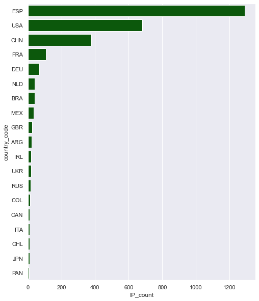

```python
sort = state_ip.sort_values("IP_count", ascending=False)[:20]

sns.set(rc = {'figure.figsize':(8,10)})
sns.barplot(data=sort, x= 'IP_count', y="country_code", color = 'darkgreen');
```

la majoria de les nostres IP es situen a Espanya, seguit d'Estats Units i la Xina.

```python
import folium

world_countries = f'/Users/deliagonzalezmata/Downloads/world-countries.json'
state_ip = state_ip #df amb columna 1 (key): country_code, col 2 (values): IP_count

m = folium.Map(location=[40.4165, -3.7026], zoom_start=1.5)

choropleth = folium.Choropleth(
    geo_data=world_countries,
    name="choropleth",
    data=state_ip,
    columns=["country_code", "IP_count"],
    key_on="feature.id",#key in the json file that contains country code
    fill_color="YlGn",
    fill_opacity=0.7,
    line_opacity=0.2,
    legend_name="Quantitat de IPs",
    nan_fill_color="white",
    nan_fill_opacity=0.1).add_to(m)

# afegim etiquetes amb el nom de cada país
style_function = "font-size: 10px; font-weight: bold"
choropleth.geojson.add_child(
    folium.features.GeoJsonTooltip(['name'], style=style_function, labels=False))

folium.LayerControl().add_to(m)


m
```

Make this Notebook Trusted to load map: File -> Trust Notebook

[interactive chart not shown]

```python
m.save('/Users/deliagonzalezmata/Downloads/choropleth-map-with-folium.html')
```